# Introduction

RedRibbon is fast and accurate rank-rank hypergeometric overlap library.

# Synthetic dataset

First, we prepare a synthetic dataset in a data.frame `df` for demonstration purpose. RedRibbon will be applied to this dataset in this vignette.

The column `a` and `b` are mandatory. Those column are the two lists over which the rank-rank hyper-geometric overlap is run.

```r
n <- 1000
n2 <- n %/% 2
n4 <- n %/% 4
a <- (1:n) - n2
b <- a
a[n4:(n4+n2-1)] <- rnorm(n2, sd=100)
b[n4:(n4+n2-1)] <- rnorm(n2, sd=100)
df <- data.frame(
    id = paste0("gene", 1:n),
    a = a,
    b = b)
```

`df` data frame contains half features perfectly matching perfectly between `a` and `b` and the remaining elements are random, `head(df)` gives

| id | a | b |
| --- | --- | --- |
| gene1 | -499 | -499 |
| gene2 | -498 | -498 |
| gene3 | -497 | -497 |
| gene4 | -496 | -496 |
| gene5 | -495 | -495 |
| gene6 | -494 | -494 |

# Synopsis

Load the library with

```r
library(RedRibbon)
```

Create an S3 RedRibbon object,

```r
rr <- RedRibbon(df, enrichment_mode="hyper-two-tailed")
```

Compute the enrichment and adjusted p-value with the `permutation` option set to compute the adjusted p-value and `whole` to split the overlap map into four quadrants (down-down, up-up, down-up, up-down),

```r
quad <- quadrants(rr, algorithm="ea", permutation=TRUE, whole=FALSE)
```

# Plots

Plots the results,

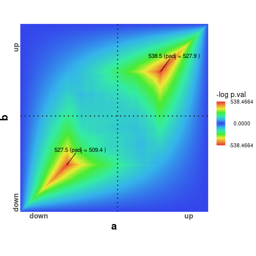

```r
gg <- ggRedRibbon(rr, quadrants=quad) + coord_fixed(ratio = 1)
gg
```

The `gg` variable contains a standard ggplot2 object,

```r
class(gg)
```

```
#> [1] "gg"     "ggplot"
```

It can be manipulated a such, for example, with `+ coord_fixed(ratio = 1)` to fix the aspect ratio of the plot.

# Enrichment statistics

The list of genes enriched in the down-down direction given with `df[quad$downdown$positions,]`. Here are the 6 first rows,

| id | a | b |
| --- | --- | --- |
| gene1 | -499 | -499 |
| gene2 | -498 | -498 |
| gene3 | -497 | -497 |
| gene4 | -496 | -496 |
| gene5 | -495 | -495 |
| gene6 | -494 | -494 |

The following statistics are available,

```r
names(quad$downdown)
```

```
#> [1] "pvalue"     "log_pvalue" "direction"  "count"      "positions"
#> [6] "i"          "j"          "padj"       "log_padj"
```

`(i , j)` is the minimal p-value coordinate on the enrichment map, `pvalue` and `log_pvalue` are the minimal p-value, `direction` is the direction of the enrichment (same direction is postive – up-up, down-down –, opposite is negative – down-up, up-down) and `count` is the number of genes overlapping.

# Compatibility mode

This mode only exists for compatibility and is obsolete. Please use the new interface shown here above.

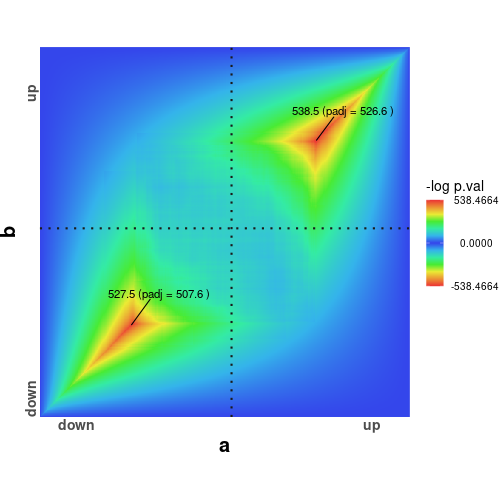

```r
compat <- RRHO(df[,c("id", "a")], df[,c("id", "b")], plots=TRUE, stepsize=n %/% 10)
compat$gg
```

```r
compat$hypermat
```

| 6.2146081 | 1.599488 | 0.9113032 | 0.5074978 | 0.2206467 | 0.00000 | 0.00000 | 0.00000 | 0.00000 | 0.00000 |
| --- | --- | --- | --- | --- | --- | --- | --- | --- | --- |
| 1.5994876 | 323.407415 | 186.9659940 | 134.3809376 | 100.1731011 | 74.71554 | 54.41844 | 37.53391 | 23.07615 | 10.43362 |
| 0.9113032 | 186.965994 | 475.0527977 | 302.0567739 | 216.5093105 | 157.71590 | 112.69239 | 80.99603 | 49.80766 | 22.84072 |
| 0.5074978 | 134.380938 | 295.5276148 | 314.6438671 | 220.2924370 | 163.17882 | 130.17113 | 106.23994 | 80.72915 | 37.03159 |
| 0.2206467 | 100.173101 | 216.5093105 | 220.2924370 | 169.2122468 | 142.26433 | 125.89378 | 146.07570 | 117.42073 | 53.60806 |
| 0.0000000 | 74.715544 | 163.5276977 | 166.2362014 | 142.2643314 | 132.70079 | 139.62760 | 188.45095 | 162.58844 | 73.54086 |
| 0.0000000 | 54.418439 | 117.9956800 | 127.1592357 | 123.5116117 | 123.77224 | 163.46803 | 229.68895 | 221.52119 | 98.55263 |
| 0.0000000 | 37.533906 | 80.9960306 | 109.8207461 | 136.1244060 | 171.89169 | 236.82383 | 335.48557 | 307.33575 | 132.18593 |
| 0.0000000 | 23.076151 | 49.8076561 | 80.7291462 | 117.4207319 | 162.58844 | 221.52119 | 307.33575 | 482.88560 | 183.96172 |
| 0.0000000 | 10.433620 | 22.8407239 | 37.0315940 | 53.6080633 | 73.54086 | 98.55263 | 132.18593 | 183.96172 | 319.02181 |

# Using and computing correlation between genes to compute adjusted p-value

Create an artificial expression matrix of n.genes by n.samples with a some fold change between non treated and treated conditions. Add r genes correlated,

```r
gen.expression.matrix <- function (n.genes, n.samples, fc=NULL, r = NULL)
{
    n.treated <- n.samples %/% 2
    n.non.treated <- n.samples - n.treated

    mat.non.treated <- matrix( rnorm(n.genes * n.non.treated, sd=10), nrow = n.genes)
    mat.fc <- if (is.null(fc)) 0 else mat.non.treated * fc
    mat.treated <- matrix(mat.fc + rnorm(n.genes * n.non.treated, sd=10) , nrow = n.genes)
    mat <- cbind(
                 mat.non.treated,
                 mat.treated)
    if ( ! is.null(r) )
        mat[1:length(r), ] <- tail(mat, length(r)) * r + (1-abs(r)) * head(mat, length(r))
    mat
}

n <- 50
n.frac <- 5
fc_a <- c(rnorm(n-n.frac), rep(-2, n.frac))
fc_b <- c(rnorm(n-n.frac), rep(-2, n.frac))
df <- data.frame(a=fc_a, b=fc_b)

mat_b <- gen.expression.matrix(n, 6, fc=fc_b, r=c(1, -1))
```

To compute the correlation,

```r
correlation <- rrho_expression_prediction(mat_b)
c.obj <- newFC(correlation$index, correlation$beta[,2])
c.obj
```

```
#> $deps
#>  [1] -1 -1 -1 -1 -1 -1 -1 -1 -1 -1 -1 -1 -1 -1 -1 -1 -1 -1 -1 -1 -1 -1 -1 -1 -1
#> [26] -1 -1 -1 -1 -1 -1 -1 -1 -1 -1 -1 -1 -1 -1 -1 -1 -1 -1 -1 -1 -1 -1 -1  1  2
#>
#> $beta
#>  [1]  0  0  0  0  0  0  0  0  0  0  0  0  0  0  0  0  0  0  0  0  0  0  0  0  0
#> [26]  0  0  0  0  0  0  0  0  0  0  0  0  0  0  0  0  0  0  0  0  0  0  0  1 -1
#>
#> attr(,"class")
#> [1] "fc"
```

Now, use it in RedRibbon,

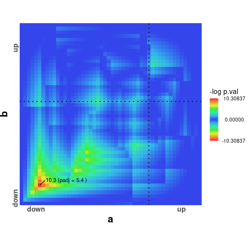

```r
rr <- RedRibbon(df, enrichment_mode="hyper-two-tailed", correlation=c.obj)
quad <- quadrants(rr, algorithm="ea", permutation=TRUE, whole=FALSE)
gg <- ggRedRibbon(rr, quadrants=quad) + coord_fixed(ratio = 1)
gg
```